# Exercise 06

Author

Gonzalo Cardenal Antolin

Published

October 31, 2023

```r
library(ggplot2)
library(pheatmap)
library(tidyr)
```

## Comparison of Expression Estimates

The data set consists for 3 Normal samples and 3 Treated samples with 2.5 Mio reads each. The reads are simulated to come from genes on the human chromosome 1.

The expression values from featureCounts were created with: We use the library `Rsubread` to generate the counts

```r
library(Rsubread)
countResult1 = featureCounts(..., strandSpecific=0,
                                 GTF.featureType="exon", GTF.attrType="gene_id", useMetaFeatures=TRUE,
                                 allowMultiOverlap=TRUE, countMultiMappingReads=FALSE)
save(countResult1, file="countResult1.RData")
countResult2 = featureCounts(..., strandSpecific=0,
                                 GTF.featureType="exon", GTF.attrType="gene_id", useMetaFeatures=TRUE,
                                 allowMultiOverlap=TRUE, countMultiMappingReads=TRUE, fraction=TRUE)
save(countResult2, file="countResult2.RData")
```

The RSEM data were generated with

```bash
rsem-calculate-expression .... --calc-pme --calc-ci --strandedness none ...
```

For documentation see: http://deweylab.github.io/RSEM/rsem-calculate-expression.html

## Exercises

### 1. Depending on the featureCount mode, how many alignments are ignored during counting?

Data files exist in two modes: without MultiMappingReads or with MultiMappingReads and Fraction.

```r
cr1 <- readRDS("countResult1.RDS")
cr2 <- readRDS("countResult2.RDS")

cr1_unassigned <- sum(colSums(cr1$stat[-1,-1]))
cr2_unassigned <- sum(colSums(cr2$stat[-1,-1]))
```

The number of alignments ignored for the non-multimapping reads is 4.1983^{5} whereas for the multimapping mode was 3.5519^{4}.

Also we can observe total ignored alignments each sample:

```r
colSums(cr1$stat[-1,-1]) #for the non-multimapping
```

```
STAR_mapped.N1.bam STAR_mapped.N2.bam STAR_mapped.N3.bam STAR_mapped.T1.bam
             50400              54506              56323              97170
STAR_mapped.T2.bam STAR_mapped.T3.bam
             80739              80692
```

```r
colSums(cr2$stat[-1,-1]) #for the multimapping
```

```
STAR_mapped.N1.bam STAR_mapped.N2.bam STAR_mapped.N3.bam STAR_mapped.T1.bam
              3244               3723               3665              11070
STAR_mapped.T2.bam STAR_mapped.T3.bam
              6987               6830
```

### 2. Compare the counts from featureCounts with the genelevel counts from RSEM. Which genes have different values?

We gather all the samples in a unique dataset.

```r
#Load the gene data from RSEM
rsem_gN1 <- read.table('RSEM_counts/N1.genes.results', header = TRUE)
rsem_gN2 <- read.table('RSEM_counts/N2.genes.results', header = TRUE)
rsem_gN3 <- read.table('RSEM_counts/N3.genes.results', header = TRUE)
rsem_gT1 <- read.table('RSEM_counts/T1.genes.results', header = TRUE)
rsem_gT2 <- read.table('RSEM_counts/T2.genes.results', header = TRUE)
rsem_gT3 <- read.table('RSEM_counts/T3.genes.results', header = TRUE)

sample_names <- colnames(cr1$stat)[-1]

rsem <- data.frame(
  rsem_gN1 = rsem_gN1['expected_count'],
  rsem_gN2 = rsem_gN2['expected_count'],
  rsem_gN3 = rsem_gN3['expected_count'],
  rsem_gT1 = rsem_gT1['expected_count'],
  rsem_gT2 = rsem_gT2['expected_count'],
  rsem_gT3 = rsem_gT3['expected_count']
)
colnames(rsem) <- sample_names
rownames(rsem) <- rsem_gN3$gene_id

cr_counts <- cr1$counts
cr_multimap_counts <-cr2$counts

#we order based in the genes id names
rsem = rsem[rownames(cr_counts),]
```

Now that we have a comparable ordered dataset, we compare the data from featureCounts non-multimapping and RSEM.

```r
percentage_unequal<- (sum(rsem != cr_counts))/(dim(rsem)[1]*dim(rsem)[2])
paste("The percentage of unequal total counts taking into account each sample individually is", round(percentage_unequal,3))
```

```
[1] "The percentage of unequal total counts taking into account each sample individually is 0.41"
```

The way we compute the percentage gives us the amount of counts that are unequal for all the genes taking into account each sample independently. So comparison is one to one. We could also compare conditioned that for all the samples (each row) the counts are the same. This will output a higher percentage, as the condition is harder to meet.

The genes ids with different counts for at least one sample are present in the following list:

```r
comparison_result <- rsem == cr_counts
all_true_rows <- rowSums(comparison_result) == ncol(comparison_result)
genes_unequal <- rownames(rsem)[!all_true_rows]
head(genes_unequal,100)
```

```
  [1] "ENSG00000223972" "ENSG00000227232" "ENSG00000243485" "ENSG00000237613"
  [5] "ENSG00000238009" "ENSG00000233750" "ENSG00000237683" "ENSG00000268903"
  [9] "ENSG00000269981" "ENSG00000239906" "ENSG00000241860" "ENSG00000228463"
 [13] "ENSG00000241670" "ENSG00000237094" "ENSG00000250575" "ENSG00000224813"
 [17] "ENSG00000236679" "ENSG00000230021" "ENSG00000225972" "ENSG00000225630"
 [21] "ENSG00000237973" "ENSG00000229344" "ENSG00000240409" "ENSG00000248527"
 [25] "ENSG00000198744" "ENSG00000185097" "ENSG00000229376" "ENSG00000224956"
 [29] "ENSG00000235373" "ENSG00000240618" "ENSG00000228327" "ENSG00000230092"
 [33] "ENSG00000240453" "ENSG00000177757" "ENSG00000228794" "ENSG00000230699"
 [37] "ENSG00000241180" "ENSG00000223764" "ENSG00000187634" "ENSG00000268179"
 [41] "ENSG00000188976" "ENSG00000187961" "ENSG00000187583" "ENSG00000187642"
 [45] "ENSG00000188290" "ENSG00000224969" "ENSG00000187608" "ENSG00000188157"
 [49] "ENSG00000242590" "ENSG00000217801" "ENSG00000237330" "ENSG00000131591"
 [53] "ENSG00000205231" "ENSG00000162571" "ENSG00000186891" "ENSG00000186827"
 [57] "ENSG00000078808" "ENSG00000176022" "ENSG00000184163" "ENSG00000160087"
 [61] "ENSG00000230415" "ENSG00000162572" "ENSG00000131584" "ENSG00000169972"
 [65] "ENSG00000127054" "ENSG00000240731" "ENSG00000224051" "ENSG00000169962"
 [69] "ENSG00000107404" "ENSG00000162576" "ENSG00000175756" "ENSG00000221978"
 [73] "ENSG00000224870" "ENSG00000242485" "ENSG00000264293" "ENSG00000235098"
 [77] "ENSG00000225905" "ENSG00000179403" "ENSG00000215915" "ENSG00000160072"
 [81] "ENSG00000197785" "ENSG00000205090" "ENSG00000160075" "ENSG00000215791"
 [85] "ENSG00000236684" "ENSG00000228594" "ENSG00000197530" "ENSG00000189409"
 [89] "ENSG00000248333" "ENSG00000189339" "ENSG00000269737" "ENSG00000269227"
 [93] "ENSG00000215914" "ENSG00000008128" "ENSG00000268575" "ENSG00000227775"
 [97] "ENSG00000215790" "ENSG00000008130" "ENSG00000078369" "ENSG00000178821"
```

There are a total of 2582 genes with different counts. The percentage for gene ids with different counts for at least one sample is 0.4938791.

Now we plot the distribution of the unequal counts and compare it to the equal ones.

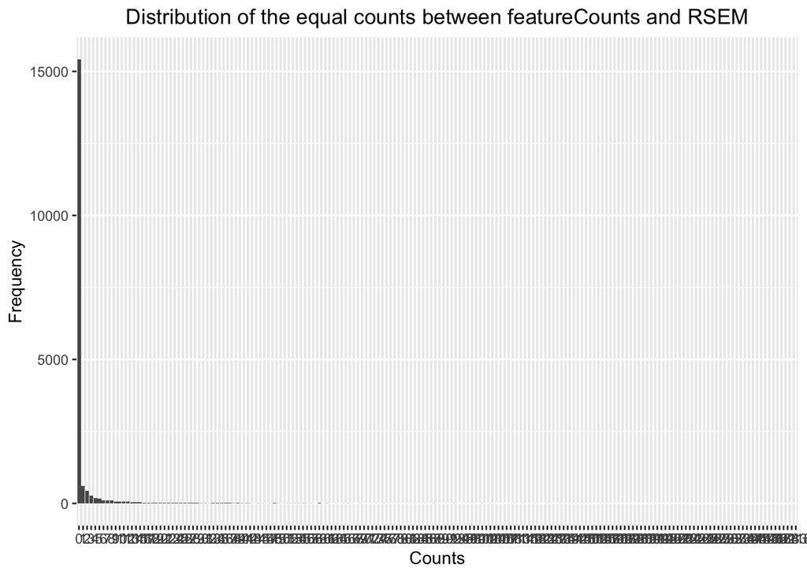

```r
unequal_counts = table(cr_counts[rsem != cr_counts])
equal_counts = table(cr_counts[rsem == cr_counts])

barplot_equal_counts = ggplot(data.frame(equal_counts), aes(x = Var1, y = Freq)) +
  geom_bar(stat = 'identity') +
  labs(title = "Distribution of the equal counts between featureCounts and RSEM", x = "Counts", y = "Frequency") +
  theme(plot.title = element_text(hjust = 0.5))
print(barplot_equal_counts)
```

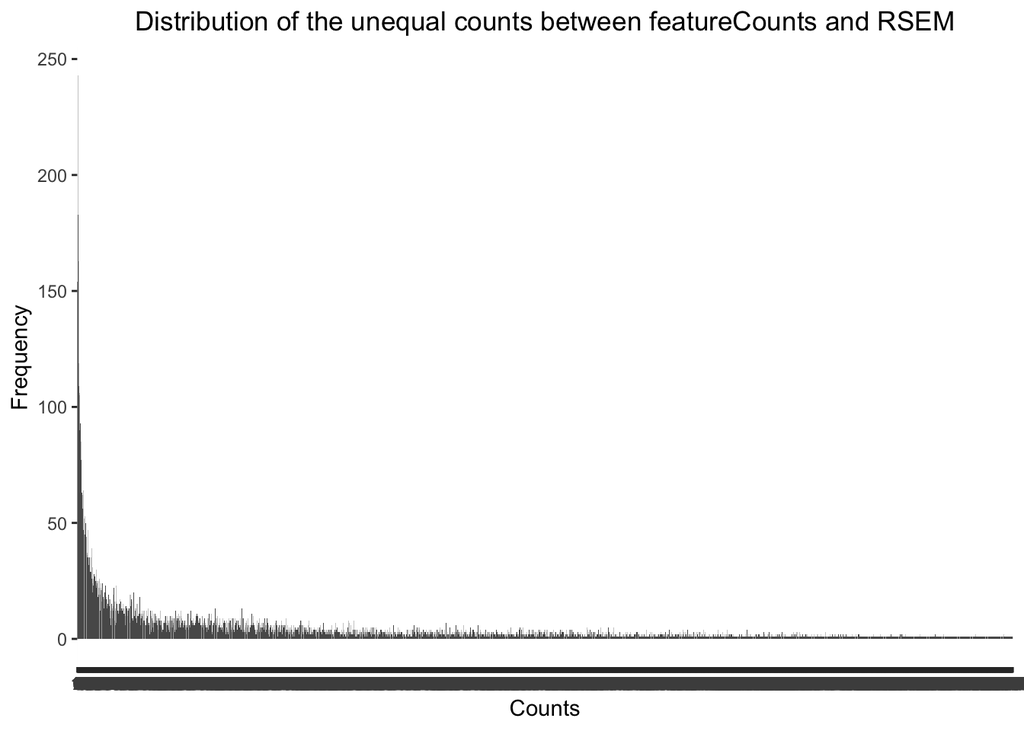

```r
barplot_unequal_counts = ggplot(data.frame(unequal_counts), aes(x = Var1, y = Freq)) +
  geom_bar(stat = 'identity') +
  labs(title = "Distribution of the unequal counts between featureCounts and RSEM", x = "Counts", y = "Frequency") +
  theme(plot.title = element_text(hjust = 0.5))
print(barplot_unequal_counts)
```

Looking at both plots we can observe that the majority of equal counts are for genes with lower or 0 counts, whereas different counts between methods are more likely to occur for higher counts (genes with higher expression).

*Now we run the same procedure against the multimapping mode.*

```r
rsem = rsem[rownames(cr_multimap_counts),]
percentage_unequal_mm<- (sum(rsem != cr_multimap_counts))/(dim(rsem)[1]*dim(rsem)[2])
paste("The percentage of unequal total counts taking into account all the samples is ", round(percentage_unequal_mm,3))
```

```
[1] "The percentage of unequal total counts taking into account all the samples is  0.437"
```

```r
comparison_result_mm <- rsem == cr_multimap_counts
all_true_rows_mm <- rowSums(comparison_result_mm) == ncol(comparison_result_mm)
genes_unequal_mm <- rownames(rsem)[!all_true_rows_mm]
head(genes_unequal_mm,100)
```

```
  [1] "ENSG00000223972" "ENSG00000227232" "ENSG00000243485" "ENSG00000237613"
  [5] "ENSG00000238009" "ENSG00000239945" "ENSG00000233750" "ENSG00000237683"
  [9] "ENSG00000268903" "ENSG00000269981" "ENSG00000239906" "ENSG00000241860"
 [13] "ENSG00000241599" "ENSG00000228463" "ENSG00000241670" "ENSG00000237094"
 [17] "ENSG00000250575" "ENSG00000233653" "ENSG00000224813" "ENSG00000269732"
 [21] "ENSG00000236679" "ENSG00000230021" "ENSG00000223659" "ENSG00000225972"
 [25] "ENSG00000225630" "ENSG00000237973" "ENSG00000229344" "ENSG00000240409"
 [29] "ENSG00000248527" "ENSG00000198744" "ENSG00000185097" "ENSG00000229376"
 [33] "ENSG00000224956" "ENSG00000235373" "ENSG00000240618" "ENSG00000229905"
 [37] "ENSG00000228327" "ENSG00000237491" "ENSG00000230092" "ENSG00000240453"
 [41] "ENSG00000177757" "ENSG00000228794" "ENSG00000230368" "ENSG00000230699"
 [45] "ENSG00000241180" "ENSG00000223764" "ENSG00000187634" "ENSG00000268179"
 [49] "ENSG00000188976" "ENSG00000187961" "ENSG00000187583" "ENSG00000187642"
 [53] "ENSG00000188290" "ENSG00000224969" "ENSG00000187608" "ENSG00000188157"
 [57] "ENSG00000242590" "ENSG00000217801" "ENSG00000237330" "ENSG00000131591"
 [61] "ENSG00000223823" "ENSG00000205231" "ENSG00000162571" "ENSG00000186891"
 [65] "ENSG00000186827" "ENSG00000078808" "ENSG00000176022" "ENSG00000184163"
 [69] "ENSG00000260179" "ENSG00000160087" "ENSG00000230415" "ENSG00000162572"
 [73] "ENSG00000131584" "ENSG00000169972" "ENSG00000127054" "ENSG00000240731"
 [77] "ENSG00000224051" "ENSG00000169962" "ENSG00000107404" "ENSG00000162576"
 [81] "ENSG00000175756" "ENSG00000221978" "ENSG00000224870" "ENSG00000242485"
 [85] "ENSG00000264293" "ENSG00000235098" "ENSG00000225905" "ENSG00000205116"
 [89] "ENSG00000225285" "ENSG00000179403" "ENSG00000215915" "ENSG00000160072"
 [93] "ENSG00000197785" "ENSG00000205090" "ENSG00000160075" "ENSG00000215791"
 [97] "ENSG00000236684" "ENSG00000228594" "ENSG00000197530" "ENSG00000189409"
```

For the multimapping mode, there are a total of 2838 genes with different counts.The percentage for gene ids with different counts for at least one sample is 0.5428462.

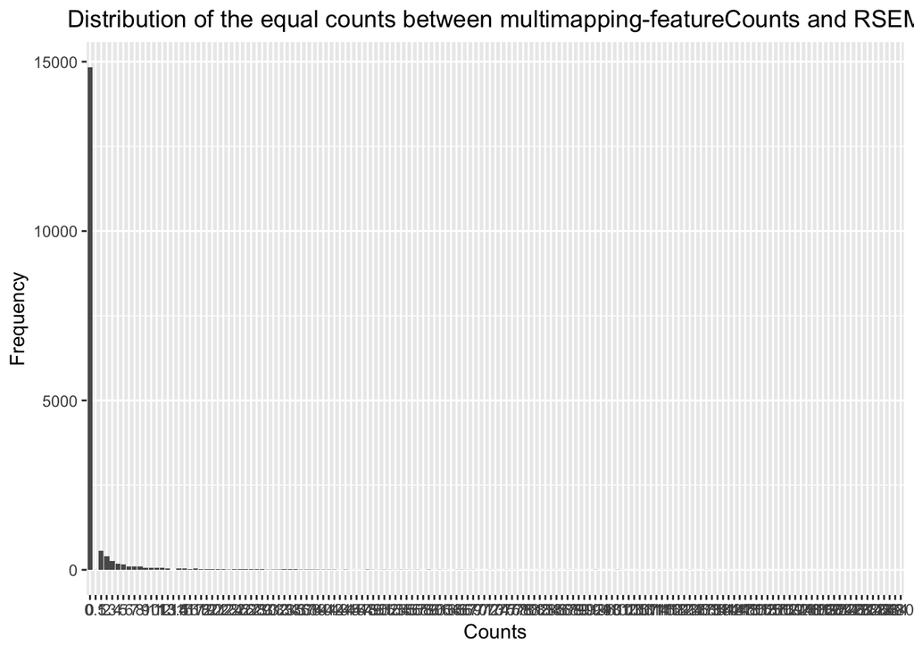

```r
unequal_counts = table(cr_multimap_counts[rsem != cr_multimap_counts])
equal_counts = table(cr_multimap_counts[rsem == cr_multimap_counts])

barplot_equal_counts = ggplot(data.frame(equal_counts), aes(x = Var1, y = Freq)) +
  geom_bar(stat = 'identity') +
  labs(title = "Distribution of the equal counts between multimapping-featureCounts and RSEM", x = "Counts", y = "Frequency") +
  theme(plot.title = element_text(hjust = 0.5))
print(barplot_equal_counts)
```

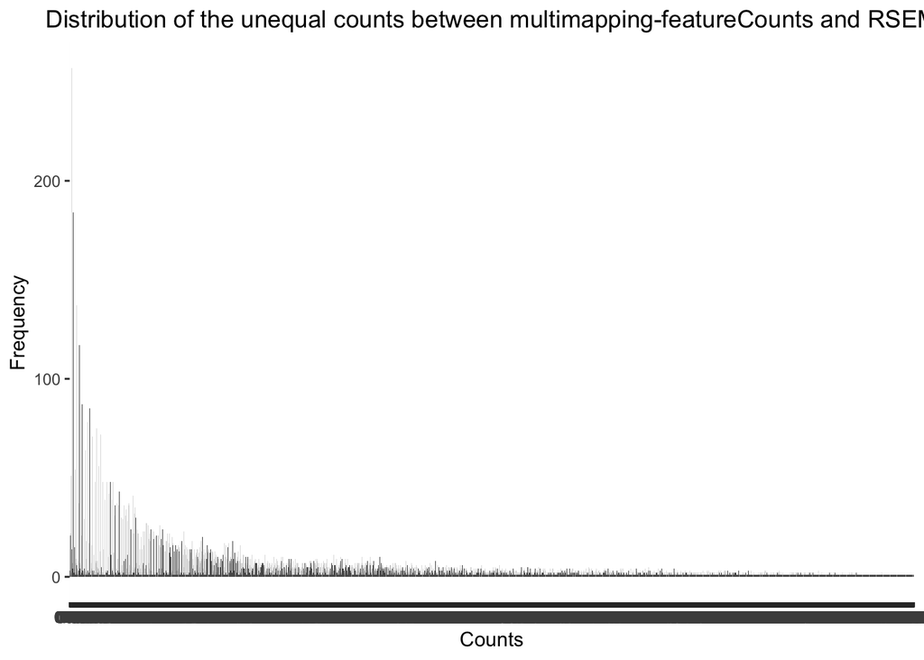

```r
barplot_unequal_counts = ggplot(data.frame(unequal_counts), aes(x = Var1, y = Freq)) +
  geom_bar(stat = 'identity') +
  labs(title = "Distribution of the unequal counts between multimapping-featureCounts and RSEM", x = "Counts", y = "Frequency") +
  theme(plot.title = element_text(hjust = 0.5))
print(barplot_unequal_counts)
```

The same observation also holds, where the tendency is that for lower or 0 counts values are the same, meanwhile for longer counts datasets have different amounts of counts.

### 3. How does the sum of the counts in RSEM compare to the number of the aligned reads?

To compare the total sum of the counts to the aligned reads we create another dataset with the aligned reads.

```r
total_counts_rsem <- colSums(rsem)
total_counts_rsem
```

```
STAR_mapped.N1.bam STAR_mapped.N2.bam STAR_mapped.N3.bam STAR_mapped.T1.bam
           2410621            2411935            2411696            2412459
STAR_mapped.T2.bam STAR_mapped.T3.bam
           2410414            2412864
```

```r
#Load the aligned data from RSEM
rsem_aN1 <- as.numeric(unlist(strsplit(
  readLines('RSEM_counts/N1.stat/N1.cnt', n=1), split = " "
)))
rsem_aN2 <- as.numeric(unlist(strsplit(
  readLines('RSEM_counts/N2.stat/N2.cnt', n=1), split = " "
)))
rsem_aN3 <- as.numeric(unlist(strsplit(
  readLines('RSEM_counts/N3.stat/N3.cnt', n=1), split = " "
)))

rsem_aT1 <- as.numeric(unlist(strsplit(
  readLines('RSEM_counts/T1.stat/T1.cnt', n=1), split = " "
)))
rsem_aT2 <- as.numeric(unlist(strsplit(
  readLines('RSEM_counts/T2.stat/T2.cnt', n=1), split = " "
)))
rsem_aT3 <- as.numeric(unlist(strsplit(
  readLines('RSEM_counts/T3.stat/T3.cnt', n=1), split = " "
)))

rsem_aligned <- data.frame(
  rsem_aN1 = rsem_aN1[2],
  rsem_aN2 = rsem_aN2[2],
  rsem_aN3 = rsem_aN3[2],
  rsem_aT1 = rsem_aT1[2],
  rsem_aT2 = rsem_aT2[2],
  rsem_aT3 = rsem_aT3[2]
)
colnames(rsem_aligned) <- sample_names

percentage_aligned <- rsem_aligned/total_counts_rsem
difference_aligned <- rsem_aligned-total_counts_rsem
difference_aligned
```

```
  STAR_mapped.N1.bam STAR_mapped.N2.bam STAR_mapped.N3.bam STAR_mapped.T1.bam
1              40.01              38.98              38.99              40.94
  STAR_mapped.T2.bam STAR_mapped.T3.bam
1              32.03              33.98
```

```r
percentage_aligned
```

```
  STAR_mapped.N1.bam STAR_mapped.N2.bam STAR_mapped.N3.bam STAR_mapped.T1.bam
1           1.000017           1.000016           1.000016           1.000017
  STAR_mapped.T2.bam STAR_mapped.T3.bam
1           1.000013           1.000014
```

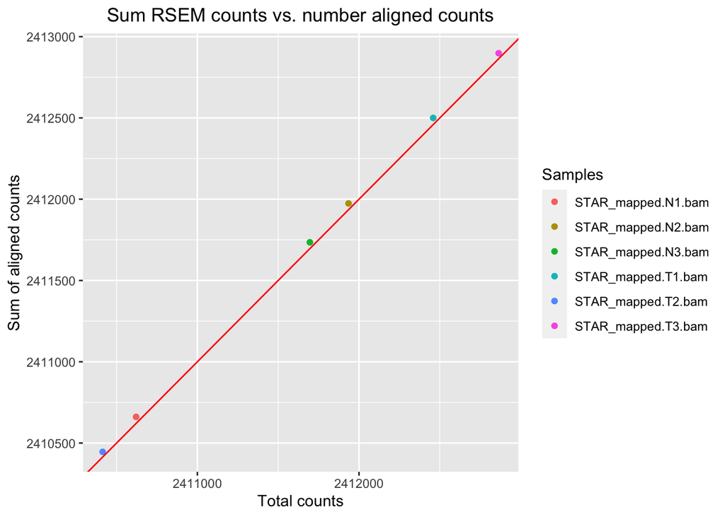

```r
aligned_df = gather(rsem_aligned, key='Samples',value ='Aligned_counts')
aligned_df$total_counts = colSums(rsem)
ggplot(data = aligned_df,
       mapping = aes(x = total_counts, y = Aligned_counts , color = Samples)) +
  geom_point() +
  labs(title = "Sum RSEM counts vs. number aligned counts",
       x = "Total counts",
       y = "Sum of aligned counts")+
  geom_abline(intercept = 0, slope = 1, color = "red") +
theme(plot.title = element_text(hjust = 0.5))
```

The difference and the percentage indicate the amount of aligned sequences is slightly above the amount of total counts, although this difference is minimum. This could indicate some counts have been aligned to more than one gene. In the plot we could also observe sample are slightly above the line.

### 4. Compute pair-wise correlation of the samples based on the isoform counts and gene level counts

We first compute the pair-wise correlation for gene level counts:

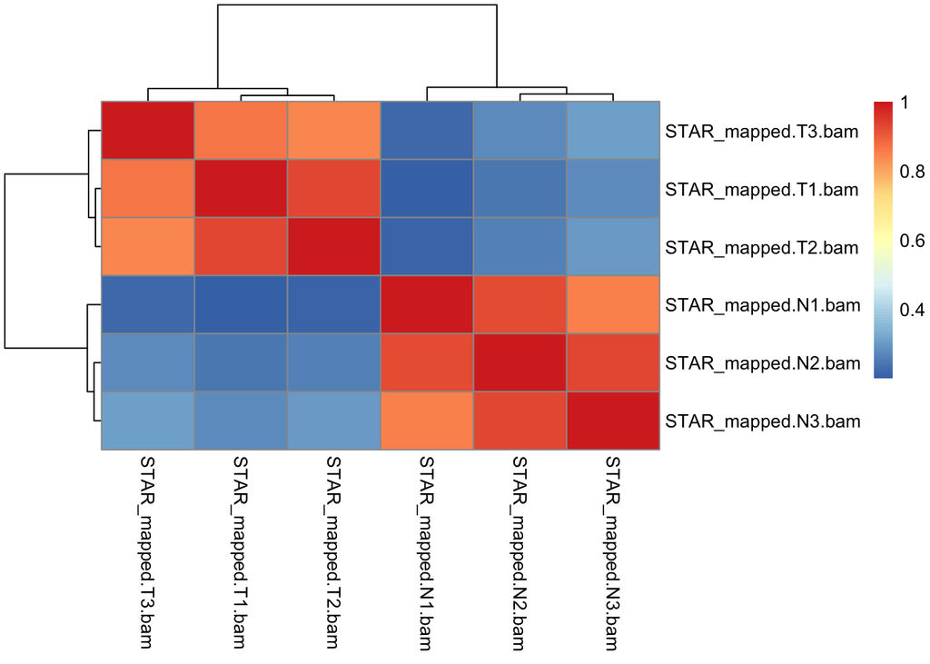

```r
correlation_genes <- cor(rsem)
pheatmap(correlation_genes)
```

Then, for the isoform level:

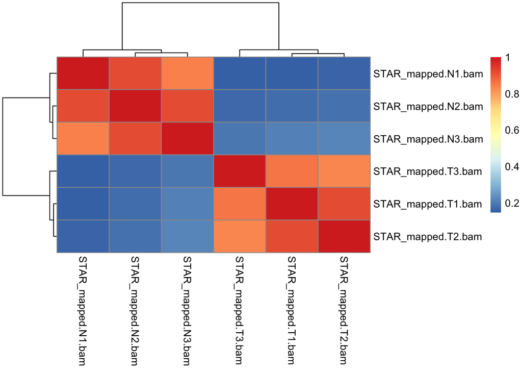

```r
#Load the isoform data from RSEM
rsem_iN1 <- read.table('RSEM_counts/N1.isoforms.results', header = TRUE)
rsem_iN2 <- read.table('RSEM_counts/N2.isoforms.results', header = TRUE)
rsem_iN3 <- read.table('RSEM_counts/N3.isoforms.results', header = TRUE)
rsem_iT1 <- read.table('RSEM_counts/T1.isoforms.results', header = TRUE)
rsem_iT2 <- read.table('RSEM_counts/T2.isoforms.results', header = TRUE)
rsem_iT3 <- read.table('RSEM_counts/T3.isoforms.results', header = TRUE)

sample_names <- colnames(cr1$stat)[-1]

rsem_isoforms <- data.frame(
  rsem_iN1 = rsem_iN1['expected_count'],
  rsem_iN2 = rsem_iN2['expected_count'],
  rsem_iN3 = rsem_iN3['expected_count'],
  rsem_iT1 = rsem_iT1['expected_count'],
  rsem_iT2 = rsem_iT2['expected_count'],
  rsem_iT3 = rsem_iT3['expected_count']
)
colnames(rsem_isoforms) <- sample_names
rownames(rsem_isoforms) <- rsem_iN3$transcript_id

correlation_transcripts <- cor(rsem_isoforms)
pheatmap(correlation_transcripts)
```

In both heatmaps the correlations are high between all the three normal samples and each other and the three treated samples and its replicates.

Finally, we can also do it for the aggregated isoforms of each gene.

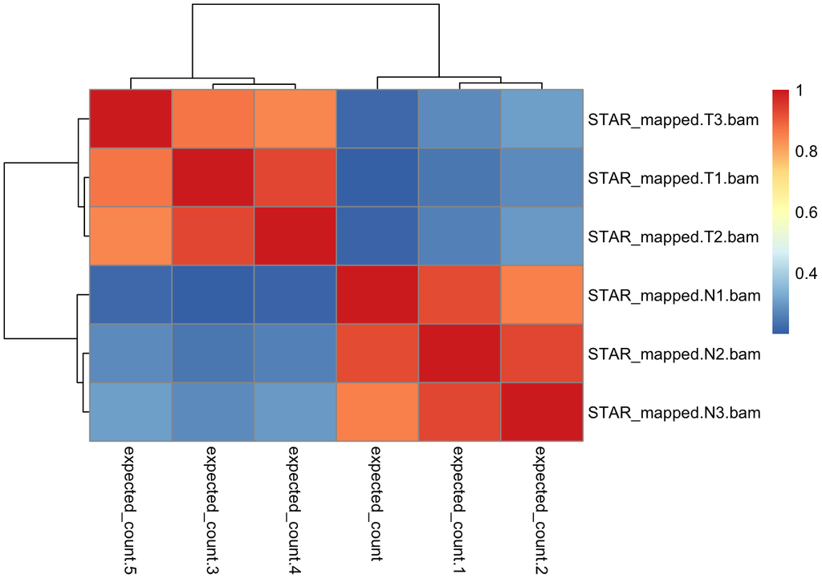

```r
rsem_isoforms$gene_id <- rsem_iN3$gene_id

rsem_iN1_sum <- aggregate(STAR_mapped.N1.bam ~ gene_id, data = rsem_isoforms, FUN = sum)
rsem_iN2_sum <- aggregate(STAR_mapped.N2.bam ~ gene_id, data = rsem_isoforms, FUN = sum)
rsem_iN3_sum <- aggregate(STAR_mapped.N3.bam ~ gene_id, data = rsem_isoforms, FUN = sum)
rsem_iT1_sum <- aggregate(STAR_mapped.T1.bam ~ gene_id, data = rsem_isoforms, FUN = sum)
rsem_iT2_sum <- aggregate(STAR_mapped.T2.bam ~ gene_id, data = rsem_isoforms, FUN = sum)
rsem_iT3_sum <- aggregate(STAR_mapped.T3.bam ~ gene_id, data = rsem_isoforms, FUN = sum)

rsem_isoforms_sum <- data.frame(
  rsem_iN1_sum[,2], rsem_iN2_sum[,2], rsem_iN3_sum[,2], rsem_iT1_sum[,2], rsem_iT2_sum[,2], rsem_iT3_sum[,2]
)
colnames(rsem_isoforms_sum) <- sample_names

#because we reordered rsem before, we define it again to do the correlation
rsem <- data.frame(
  rsem_gN1 = rsem_gN1['expected_count'],
  rsem_gN2 = rsem_gN2['expected_count'],
  rsem_gN3 = rsem_gN3['expected_count'],
  rsem_gT1 = rsem_gT1['expected_count'],
  rsem_gT2 = rsem_gT2['expected_count'],
  rsem_gT3 = rsem_gT3['expected_count']
)

correlation_iso_genes<- cor(rsem_isoforms_sum, rsem)
pheatmap(correlation_iso_genes)
```

Aggregated isoforms corralate with genes again between normal samples and each other and treated samples and each other.